# ET_PROJECT

**Ensemble Techniques project**

**DOMAIN**: Telecom

**CONTEXT**: A telecom company wants to use their historical customer data to predict behaviour to retain customers. You can analyse all relevant customer data and develop focused customer retention programs.

**DATA DESCRIPTION**: Each row represents a customer, each column contains customer’s attributes described on the column Metadata. The data set includes information about:

1. Customers who left within the last month – the column is called Churn
2. Services that each customer has signed up for – phone, multiple lines, internet, online security, online backup, device protection, tech support, and streaming TV and movies
3. Customer account information – how long they’ve been a customer, contract, payment method, paperless billing, monthly charges, and total charges
4. Demographic info about customers – gender, age range, and if they have partners and dependents

**PROJECT OBJECTIVE**: Build a model that will help to identify the potential customers who have a higher probability to churn. This help the company to understand the pinpoints and patterns of customer churn and will increase the focus on strategising customer retention.

Steps to the project: [ Total score: 60 points ]

**Step 1: Import and warehouse data**: [ Score: 5 point ]

Import all the given datasets. Explore shape and size. Merge all datasets onto one and explore final shape and size.

```python
# Import Pythin libraries
import numpy as np
import pandas as pd
import matplotlib.pyplot as plt
import seaborn as sns
#import pandas_profiling

import warnings
warnings.filterwarnings('ignore')

from IPython.core.interactiveshell import InteractiveShell
InteractiveShell.ast_node_interactivity = "all"
%matplotlib inline

from sklearn import tree
from sklearn.model_selection import  cross_val_score
from sklearn.model_selection import train_test_split
from sklearn.ensemble import RandomForestClassifier, RandomForestRegressor, GradientBoostingClassifier, BaggingClassifier
from sklearn.metrics import classification_report, confusion_matrix, accuracy_score
from sklearn.metrics import roc_auc_score
from sklearn.metrics import roc_curve
from matplotlib import pyplot
from sklearn.metrics import precision_recall_curve
from xgboost import XGBClassifier
from imblearn.over_sampling import SMOTE

import graphviz
import pickle
```

```python
from google.colab import drive
drive.mount('/content/drive')
```

```python
#%pwd
#%cd /content/drive/MyDrive/GL_Learning/Assignments/EnsembledTechnique
#%pwd
```

```python
# Import First dataset and check shape
df1_churn = pd.read_csv("/content/drive/MyDrive/AI_ML_course/NAYAN_ENSEMBLE_TECHNIQUE_PROJECT/TelcomCustomer-Churn_1.csv")
df1_churn.sample(5)
df1_churn.shape
```

|  | customerID | gender | SeniorCitizen | Partner | Dependents | tenure | PhoneService | MultipleLines | InternetService | OnlineSecurity |
| --- | --- | --- | --- | --- | --- | --- | --- | --- | --- | --- |
| 1277 | 4821-WQOYN | Female | 0 | Yes | Yes | 72 | Yes | No | No | No internet service |
| 1276 | 7005-CYUIL | Female | 1 | Yes | No | 71 | Yes | No | Fiber optic | Yes |
| 4177 | 3470-BTGQO | Male | 0 | No | Yes | 21 | Yes | No | DSL | No |
| 4509 | 2013-SGDXK | Female | 0 | No | No | 1 | Yes | No | Fiber optic | No |
| 6514 | 6166-YIPFO | Male | 0 | Yes | No | 72 | No | No phone service | DSL | Yes |

```
(7043, 10)
```

```python
# Import Second dataset and Check shape
df2_churn = pd.read_csv("/content/drive/MyDrive/AI_ML_course/NAYAN_ENSEMBLE_TECHNIQUE_PROJECT/TelcomCustomer-Churn_2.csv")
df2_churn.sample(5)
df2_churn.shape
```

|  | customerID | OnlineBackup | DeviceProtection | TechSupport | StreamingTV | StreamingMovies | Contract | PaperlessBilling | PaymentMethod | MonthlyCharges | TotalCharges | Churn |
| --- | --- | --- | --- | --- | --- | --- | --- | --- | --- | --- | --- | --- |
| 1063 | 7143-BQIBA | No | No | Yes | Yes | No | Month-to-month | No | Bank transfer (automatic) | 62.25 | 612.95 | No |
| 4091 | 8263-OKETD | Yes | No | Yes | No | Yes | Month-to-month | Yes | Credit card (automatic) | 68.90 | 1370.35 | No |
| 2263 | 2506-CLAKW | Yes | Yes | Yes | No | Yes | Month-to-month | Yes | Bank transfer (automatic) | 98.15 | 567.45 | Yes |
| 2002 | 0017-DINOC | No | No | Yes | Yes | No | Two year | No | Credit card (automatic) | 45.20 | 2460.55 | No |
| 6568 | 5647-URDKA | No internet service | No internet service | No internet service | No internet service | No internet service | Two year | No | Mailed check | 19.70 | 130.25 | No |

```
(7043, 12)
```

```python
# Merge two datasets to get churn data
frames = [df1_churn,df2_churn]
df_churn = pd.concat(frames,axis=1,verify_integrity=False)
df_churn.sample(5)
```

|  | customerID | gender | SeniorCitizen | Partner | Dependents | tenure | PhoneService | MultipleLines | InternetService | OnlineSecurity | ... | DeviceProtection | TechSupport | StreamingTV | StreamingMovies | Contract | PaperlessBilling | PaymentMethod | MonthlyCharges | TotalCharges | Churn |
| --- | --- | --- | --- | --- | --- | --- | --- | --- | --- | --- | --- | --- | --- | --- | --- | --- | --- | --- | --- | --- | --- |
| 4059 | 3415-TAILE | Female | 0 | Yes | Yes | 2 | Yes | No | DSL | No | ... | No | No | Yes | Yes | Month-to-month | No | Mailed check | 65.70 | 134.35 | Yes |
| 3821 | 1833-VGRUM | Female | 1 | No | No | 1 | Yes | Yes | Fiber optic | No | ... | No | No | No | No | Month-to-month | Yes | Electronic check | 74.20 | 74.2 | Yes |
| 3145 | 2919-HBCJO | Female | 0 | No | No | 4 | Yes | No | Fiber optic | No | ... | No | No | No | No | Month-to-month | Yes | Bank transfer (automatic) | 76.65 | 333.6 | Yes |
| 6783 | 9867-XOBQA | Female | 0 | No | Yes | 21 | No | No phone service | DSL | Yes | ... | Yes | Yes | Yes | No | Two year | No | Mailed check | 53.15 | 1183.2 | No |
| 642 | 0970-ETWGE | Male | 0 | No | No | 1 | Yes | No | Fiber optic | No | ... | No | No | Yes | Yes | Month-to-month | Yes | Electronic check | 89.55 | 89.55 | Yes |

5 rows × 22 columns

```python
# Check size of data
df_churn.shape
```

```
(7043, 22)
```

## **Data cleansing**: [ Score: 10 point ]

Missing value treatment, Convert categorical attributes to continuous using relevant functional knowledge, Drop attribute/s if required using relevant functional knowledge, Automate all the above steps

```python
# Checking standard null values in data
df_churn.isnull().sum()
```

```
customerID          0
gender              0
SeniorCitizen       0
Partner             0
Dependents          0
tenure              0
PhoneService        0
MultipleLines       0
InternetService     0
OnlineSecurity      0
customerID          0
OnlineBackup        0
DeviceProtection    0
TechSupport         0
StreamingTV         0
StreamingMovies     0
Contract            0
PaperlessBilling    0
PaymentMethod       0
MonthlyCharges      0
TotalCharges        0
Churn               0
dtype: int64
```

### Observation 2

1. No standard null values present in data with existing datatype

```python
# Check data types
df_churn.dtypes
```

```
customerID           object
gender               object
SeniorCitizen         int64
Partner              object
Dependents           object
tenure                int64
PhoneService         object
MultipleLines        object
InternetService      object
OnlineSecurity       object
customerID           object
OnlineBackup         object
DeviceProtection     object
TechSupport          object
StreamingTV          object
StreamingMovies      object
Contract             object
PaperlessBilling     object
PaymentMethod        object
MonthlyCharges      float64
TotalCharges         object
Churn                object
dtype: object
```

### Observation 4

1. Lot of the columns are object types, we need to inspect them for null values and incorrect data.
2. Also we need to change variable datatype to correct one based on functional information. and then check for null and na values.

```python
# Print column names
df_churn.columns
```

```
Index(['customerID', 'gender', 'SeniorCitizen', 'Partner', 'Dependents',
       'tenure', 'PhoneService', 'MultipleLines', 'InternetService',
       'OnlineSecurity', 'customerID', 'OnlineBackup', 'DeviceProtection',
       'TechSupport', 'StreamingTV', 'StreamingMovies', 'Contract',
       'PaperlessBilling', 'PaymentMethod', 'MonthlyCharges', 'TotalCharges',
       'Churn'],
      dtype='object')
```

```python
#Intended Type of attributes based on problem/functional information#
#'customerID', 'gender', 'SeniorCitizen', 'Partner', 'Dependents','tenure',
#'PhoneService', 'MultipleLines', 'InternetService','OnlineSecurity', 'OnlineBackup',
#'DeviceProtection', 'TechSupport','StreamingTV', 'StreamingMovies', 'Contract',
#'PaperlessBilling','PaymentMethod', 'MonthlyCharges', 'TotalCharges', 'Churn

# Object attribute
obj_attr = df_churn["customerID"]

# Convert relevant columns to numerical attribute
numerics_columns = ["tenure", "MonthlyCharges", "TotalCharges"]
num_attr = df_churn[numerics_columns].apply(pd.to_numeric, errors="coerce")

# Convert relavant columns to categorical data type
catog_columns = ["gender","SeniorCitizen","Partner","Churn","PaymentMethod","PaperlessBilling","Dependents","StreamingTV","Contract","StreamingMovies","TechSupport","PhoneService","MultipleLines","InternetService","OnlineSecurity","OnlineBackup","DeviceProtection"]
cat_attr = df_churn[catog_columns].apply(pd.Categorical)

churn_data = pd.concat([obj_attr,num_attr,cat_attr], axis=1, join="inner")
```

```python
# Check data types
churn_data.dtypes
```

```
customerID            object
customerID            object
tenure                 int64
MonthlyCharges       float64
TotalCharges         float64
gender              category
SeniorCitizen       category
Partner             category
Churn               category
PaymentMethod       category
PaperlessBilling    category
Dependents          category
StreamingTV         category
Contract            category
StreamingMovies     category
TechSupport         category
PhoneService        category
MultipleLines       category
InternetService     category
OnlineSecurity      category
OnlineBackup        category
DeviceProtection    category
dtype: object
```

```python
# Check standard null values in data
churn_data.isnull().sum()
```

```
customerID           0
customerID           0
tenure               0
MonthlyCharges       0
TotalCharges        11
gender               0
SeniorCitizen        0
Partner              0
Churn                0
PaymentMethod        0
PaperlessBilling     0
Dependents           0
StreamingTV          0
Contract             0
StreamingMovies      0
TechSupport          0
PhoneService         0
MultipleLines        0
InternetService      0
OnlineSecurity       0
OnlineBackup         0
DeviceProtection     0
dtype: int64
```

### Observation 5

1. Total chaarges Attribues have 11 null values. We need to impute these values with median values. Median is chosen since it doest alter the distribution.
2. Also, 0.16% (11/7043) of null data which is very less for modelling error.

```python
# Replace null values in Total charges by median values
churn_data.fillna(churn_data.median(), inplace=True)
```

```python
# Check standard null values in data
churn_data.isnull().sum()
churn_data.isna().sum()
```

```
customerID          0
customerID          0
tenure              0
MonthlyCharges      0
TotalCharges        0
gender              0
SeniorCitizen       0
Partner             0
Churn               0
PaymentMethod       0
PaperlessBilling    0
Dependents          0
StreamingTV         0
Contract            0
StreamingMovies     0
TechSupport         0
PhoneService        0
MultipleLines       0
InternetService     0
OnlineSecurity      0
OnlineBackup        0
DeviceProtection    0
dtype: int64
```

```
customerID          0
customerID          0
tenure              0
MonthlyCharges      0
TotalCharges        0
gender              0
SeniorCitizen       0
Partner             0
Churn               0
PaymentMethod       0
PaperlessBilling    0
Dependents          0
StreamingTV         0
Contract            0
StreamingMovies     0
TechSupport         0
PhoneService        0
MultipleLines       0
InternetService     0
OnlineSecurity      0
OnlineBackup        0
DeviceProtection    0
dtype: int64
```

```python
#Checking churn balance in the data
churn_data['Churn'].value_counts()
```

```
No     5174
Yes    1869
Name: Churn, dtype: int64
```

### Observation 6

1. No churn customer percentage is 73.46% where as churn customer is 26.53%. So Classes are imbalanced.
2. Class imbalances need to be taken care during modelling either by Upsampling the churn data or Downsampling the No churn data

```python
# Look for columns with unique value, Count of unique values
for column in catog_columns:
    print("Attribute name: "+ column);
    print(churn_data[column].unique());
    print(churn_data[column].value_counts());
    print("......................................")
    print("\n")
```

```
Attribute name: gender
['Female', 'Male']
Categories (2, object): ['Female', 'Male']
Male      3555
Female    3488
Name: gender, dtype: int64
......................................


Attribute name: SeniorCitizen
[0, 1]
Categories (2, int64): [0, 1]
0    5901
1    1142
Name: SeniorCitizen, dtype: int64
......................................


Attribute name: Partner
['Yes', 'No']
Categories (2, object): ['No', 'Yes']
No     3641
Yes    3402
Name: Partner, dtype: int64
......................................


Attribute name: Churn
['No', 'Yes']
Categories (2, object): ['No', 'Yes']
No     5174
Yes    1869
Name: Churn, dtype: int64
......................................


Attribute name: PaymentMethod
['Electronic check', 'Mailed check', 'Bank transfer (automatic)', 'Credit card (automatic)']
Categories (4, object): ['Bank transfer (automatic)', 'Credit card (automatic)', 'Electronic check',
                         'Mailed check']
```

[output cut: 108 more lines]

```
No                     3088
Yes                    2429
No internet service    1526
Name: OnlineBackup, dtype: int64
......................................


Attribute name: DeviceProtection
['No', 'Yes', 'No internet service']
Categories (3, object): ['No', 'No internet service', 'Yes']
No                     3095
Yes                    2422
No internet service    1526
Name: DeviceProtection, dtype: int64
......................................
```

### Observation 3

1. No attribute has single unique value. So no attribute discarded.
2. Also, Binary categorical variables (Only two categories) can be coverted to 0/1 values
3. Catogorical variables with more than 2 types need dummy variables
4. From functional information, gender,SeniorCitizen,Partner, Dependents,PaperlessBilling,Churn, PhoneService, should be having two catogories only.
5. Attributes: Gender,Partner, have class balance
6. Only 1142 customers are senior citizens (16.21%)
7. Atributes such as Device Protection, Online Backup, Online Security, Tech support, Streaming movies, StreamingTV have "No internet service" Class. There may be high correllation in these classes with Respect to InternetService.
8. Multiple Lines has class of "No phone service". Phone service and Multiple lines may be correlated.

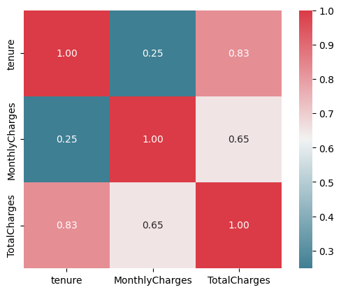

```python
cat_corr = churn_data.corr()
cmap = sns.diverging_palette(220, 10, as_cmap = True)
sns.heatmap(cat_corr,cmap=cmap, vmax = 1, square = True, annot = True, fmt = ".2f");
```

## Exploratory data analysis

### Analysis numerical variables with respect to Target variable.

1. Performing univariate analysis. Distribution plot for each numeric variable.
2. Checking an outlier using box plot.

```python
# Describe the numerical data
churn_data.describe()
```

|  | tenure | MonthlyCharges | TotalCharges |
| --- | --- | --- | --- |
| count | 7043.000000 | 7043.000000 | 7043.000000 |
| mean | 32.371149 | 64.761692 | 2281.916928 |
| std | 24.559481 | 30.090047 | 2265.270398 |
| min | 0.000000 | 18.250000 | 18.800000 |
| 25% | 9.000000 | 35.500000 | 402.225000 |
| 50% | 29.000000 | 70.350000 | 1397.475000 |
| 75% | 55.000000 | 89.850000 | 3786.600000 |
| max | 72.000000 | 118.750000 | 8684.800000 |

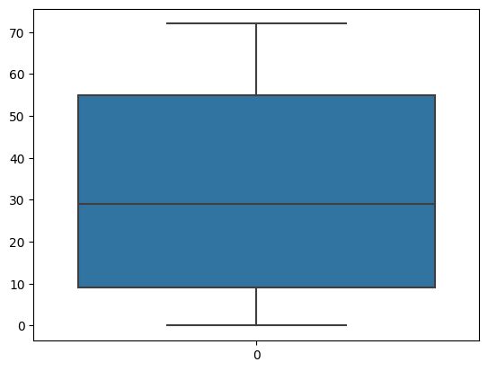

```python
sns.boxplot(churn_data["tenure"]);
```

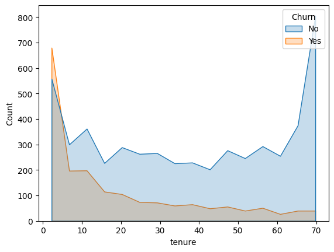

```python
sns.histplot(churn_data, x= churn_data["tenure"], hue=churn_data["Churn"], element='poly');
```

### Observation 7

1. It can be seen from the above plot that cutomer churn is high at the initial months/tenure and goes on reducing assymptotically after 25-30 months.
2. No churn customer count is high intially upto 10 months, remains near constant till 60 months and then spikes till 70 months.

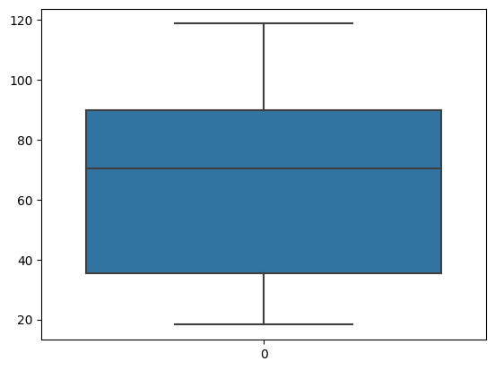

```python
sns.boxplot(churn_data["MonthlyCharges"]);
```

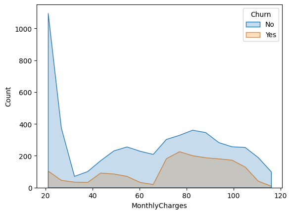

```python
sns.histplot(churn_data, x= churn_data["MonthlyCharges"], hue=churn_data["Churn"], element='poly');
```

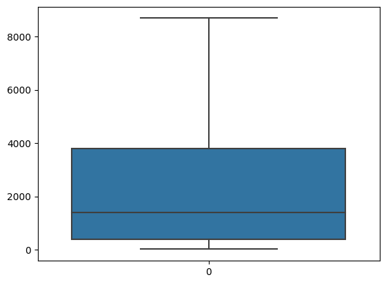

```python
sns.boxplot(churn_data["TotalCharges"]);
```

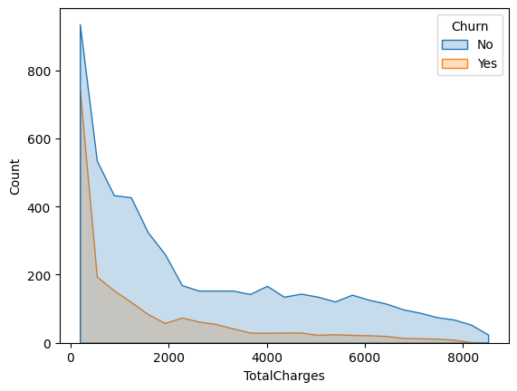

```python
sns.histplot(churn_data, x= churn_data["TotalCharges"], hue=churn_data["Churn"], element='poly');
```

```python
# Checking Churn with respect to gender
churn_data['gender'].unique()
churn_data['gender'].value_counts()
```

```
['Female', 'Male']
Categories (2, object): ['Female', 'Male']
```

```
Male      3555
Female    3488
Name: gender, dtype: int64
```

## Model building

### Converting all the catogorical columns with dummy values

```python
# Creating New dataframe for model
data = df_churn.copy()

# Converting the target class to 1’s and 0's
data['Churn'] = data['Churn'].map(lambda s :1  if s =='Yes' else 0)

#data['gender'].unique()
data = pd.get_dummies(data=data, columns=['gender'])

data['Partner'] = data['Partner'].map(lambda s :1  if s =='Yes' else 0)

data['Dependents'] = data['Dependents'].map(lambda s :1  if s =='Yes' else 0)
data['PhoneService'] = data['PhoneService'].map(lambda s :1  if s =='Yes' else 0)
data['PaperlessBilling'] = data['PaperlessBilling'].map(lambda s :1  if s =='Yes' else 0)


data['MultipleLines'].replace('No phone service','No', inplace=True)
data['MultipleLines'] = data['MultipleLines'].map(lambda s :1  if s =='Yes' else 0)

data['Has_InternetService'] = data['InternetService'].map(lambda s :0  if s =='No' else 1)
data['Fiber_optic'] = data['InternetService'].map(lambda s :1  if s =='Fiber optic' else 0)
data['DSL'] = data['InternetService'].map(lambda s :1  if s =='DSL' else 0)

data['OnlineSecurity'] = data['OnlineSecurity'].map(lambda s :1  if s =='Yes' else 0)
data['OnlineBackup'] = data['OnlineBackup'].map(lambda s :1  if s =='Yes' else 0)
data['DeviceProtection'] = data['DeviceProtection'].map(lambda s :1  if s =='Yes' else 0)
data['TechSupport'] = data['TechSupport'].map(lambda s :1  if s =='Yes' else 0)
data['StreamingTV'] = data['StreamingTV'].map(lambda s :1  if s =='Yes' else 0)
data['StreamingMovies'] = data['StreamingMovies'].map(lambda s :1  if s =='Yes' else 0)

data = pd.get_dummies(data=data, columns=['PaymentMethod'])
data = pd.get_dummies(data=data, columns=['Contract'])
```

```python
# Print data
data.sample(5)
```

|  | customerID | SeniorCitizen | Partner | Dependents | tenure | PhoneService | MultipleLines | InternetService | OnlineSecurity | customerID | ... | Has_InternetService | Fiber_optic | DSL | PaymentMethod_Bank transfer (automatic) | PaymentMethod_Credit card (automatic) | PaymentMethod_Electronic check | PaymentMethod_Mailed check | Contract_Month-to-month | Contract_One year | Contract_Two year |
| --- | --- | --- | --- | --- | --- | --- | --- | --- | --- | --- | --- | --- | --- | --- | --- | --- | --- | --- | --- | --- | --- |
| 2924 | 1428-GTBJJ | 0 | 0 | 0 | 11 | 1 | 0 | Fiber optic | 0 | 1428-GTBJJ | ... | 1 | 1 | 0 | 0 | 0 | 1 | 0 | 1 | 0 | 0 |
| 1855 | 5296-BFCYD | 0 | 1 | 1 | 46 | 1 | 0 | No | 0 | 5296-BFCYD | ... | 0 | 0 | 0 | 0 | 0 | 0 | 1 | 0 | 0 | 1 |
| 6392 | 3999-WRNGR | 0 | 1 | 1 | 60 | 0 | 0 | DSL | 0 | 3999-WRNGR | ... | 1 | 0 | 1 | 0 | 0 | 1 | 0 | 1 | 0 | 0 |
| 6628 | 9979-RGMZT | 0 | 0 | 0 | 7 | 1 | 0 | Fiber optic | 0 | 9979-RGMZT | ... | 1 | 1 | 0 | 0 | 0 | 0 | 1 | 0 | 1 | 0 |
| 1513 | 0661-XEYAN | 1 | 0 | 0 | 1 | 0 | 0 | DSL | 0 | 0661-XEYAN | ... | 1 | 0 | 1 | 0 | 0 | 0 | 1 | 1 | 0 | 0 |

5 rows × 31 columns

```python
# Drop Customer id Data (Not usefull for model building)
data=data.drop(['customerID'], axis=1)
data=data.drop(['InternetService'], axis=1)
```

```python
# Check standard null values in data
data.isnull().sum()
data.isna().sum()
```

```
SeniorCitizen                              0
Partner                                    0
Dependents                                 0
tenure                                     0
PhoneService                               0
MultipleLines                              0
OnlineSecurity                             0
OnlineBackup                               0
DeviceProtection                           0
TechSupport                                0
StreamingTV                                0
StreamingMovies                            0
PaperlessBilling                           0
MonthlyCharges                             0
TotalCharges                               0
Churn                                      0
gender_Female                              0
gender_Male                                0
Has_InternetService                        0
Fiber_optic                                0
DSL                                        0
PaymentMethod_Bank transfer (automatic)    0
PaymentMethod_Credit card (automatic)      0
PaymentMethod_Electronic check             0
PaymentMethod_Mailed check                 0
Contract_Month-to-month                    0
Contract_One year                          0
Contract_Two year                          0
dtype: int64
```

```
SeniorCitizen                              0
Partner                                    0
Dependents                                 0
tenure                                     0
PhoneService                               0
MultipleLines                              0
OnlineSecurity                             0
OnlineBackup                               0
DeviceProtection                           0
TechSupport                                0
StreamingTV                                0
StreamingMovies                            0
PaperlessBilling                           0
MonthlyCharges                             0
TotalCharges                               0
Churn                                      0
gender_Female                              0
gender_Male                                0
Has_InternetService                        0
Fiber_optic                                0
DSL                                        0
PaymentMethod_Bank transfer (automatic)    0
PaymentMethod_Credit card (automatic)      0
PaymentMethod_Electronic check             0
PaymentMethod_Mailed check                 0
Contract_Month-to-month                    0
Contract_One year                          0
Contract_Two year                          0
dtype: int64
```

```python
#Replace null values in Total charges by median values
data['TotalCharges'].apply(pd.to_numeric, errors="coerce")
data['TotalCharges'] = data['TotalCharges'].apply(pd.to_numeric, errors="coerce")
data.fillna(data.median(), inplace=True)
```

```
0         29.85
1       1889.50
2        108.15
3       1840.75
4        151.65
         ...
7038    1990.50
7039    7362.90
7040     346.45
7041     306.60
7042    6844.50
Name: TotalCharges, Length: 7043, dtype: float64
```

```python
# Convert Target variable Churn to Integer
data["Churn"] = data["Churn"].astype(int)
Y_train = data["Churn"]
X_train = data.drop(labels = ["Churn"],axis = 1)
```

## Building Random Forest Model

```python
# Creating Feature and Response data
X = data.drop(labels = ["Churn"],axis = 1)
y = data["Churn"]
```

```python
# Train Test split
X_train, X_test, y_train, y_test = train_test_split(X, y, test_size= 0.05, random_state= 42)
```

```python
# Instantialting Random Forest Classifier and Model Fitting
rf = RandomForestClassifier(n_estimators=200, max_depth=30,
                              random_state=35)
rf.fit(X_train, y_train)
Train_score = rf.score(X_train, y_train)
Test_score = rf.score(X_test, y_test)
print("Training set accuracy: ", '%.3f'%(Train_score))
print("Test set accuracy: ", '%.3f'%(Test_score))
```

```
RandomForestClassifier(max_depth=30, n_estimators=200, random_state=35)
```

```
Training set accuracy:  0.998
Test set accuracy:  0.802
```

```python
# Predicting using RF model and Probabilities
y_pred = rf.predict(X_test)
rf_probs = rf.predict_proba(X_test)
print("Confusion Matrix: \n",confusion_matrix(y_test,y_pred),"\n")
print("Classification Report: \n",classification_report(y_test,y_pred),"\n")
print(accuracy_score(y_test, y_pred))
```

```
Confusion Matrix:
 [[242  22]
 [ 48  41]]

Classification Report:
               precision    recall  f1-score   support

           0       0.83      0.92      0.87       264
           1       0.65      0.46      0.54        89

    accuracy                           0.80       353
   macro avg       0.74      0.69      0.71       353
weighted avg       0.79      0.80      0.79       353


0.8016997167138811
```

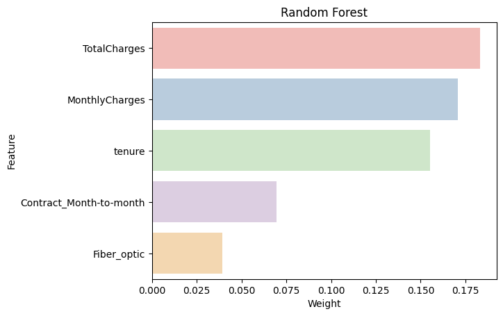

```python
# Obtaining feature importance
fi = pd.DataFrame({'Feature': list(X_train.columns),'Importance': rf.feature_importances_}).sort_values('Importance', ascending = False)
fi.head()
# Plotting it
g = sns.barplot(x=fi["Importance"][0:5],y=fi["Feature"][0:5], palette="Pastel1",orient = "h")
g.set_xlabel("Weight")
g = g.set_title("Random Forest");
```

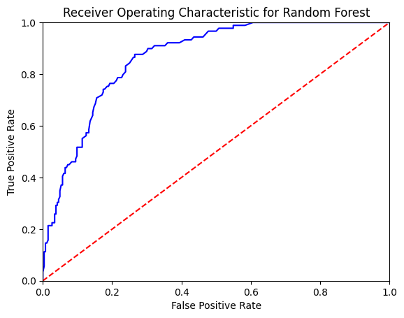

```python
# Calculate the fpr and tpr for all thresholds of the classification
fpr, tpr, threshold = roc_curve(y_test, rf_probs[:,1]);
plt.title('Receiver Operating Characteristic for Random Forest');
plt.plot(fpr, tpr, 'b');
plt.plot([0, 1], [0, 1],'r--');
plt.xlim([0, 1]);
plt.ylim([0, 1]);
plt.ylabel('True Positive Rate');
plt.xlabel('False Positive Rate');
plt.show();
```

```python
# Save the model for Future use
filename = 'RF_Churn.sav'
pickle.dump(rf , open(filename,'wb'))
```

```python
# Building model with same Train Test split
gb_model = GradientBoostingClassifier(max_depth=5, learning_rate=0.08)
gb_model.fit(X_train, y_train)
print('Accuracy of GB classifier on training set: {:.2f}'
       .format(gb_model.score(X_train, y_train)))
print('Accuracy of GB classifier on test set: {:.2f}'
       .format(gb_model.score(X_test[X_train.columns], y_test)))
```

```
GradientBoostingClassifier(learning_rate=0.08, max_depth=5)
```

```
Accuracy of GB classifier on training set: 0.86
Accuracy of GB classifier on test set: 0.80
```

```python
# Predicting using Gradient Boosting model and Probabilities
y_pred = gb_model.predict(X_test)
gb_probs = gb_model.predict_proba(X_test)
print("Confusion Matrix: \n",confusion_matrix(y_test,y_pred),"\n")
print("Classification Report: \n",classification_report(y_test,y_pred),"\n")
print(accuracy_score(y_test, y_pred))
```

```
Confusion Matrix:
 [[238  26]
 [ 46  43]]

Classification Report:
               precision    recall  f1-score   support

           0       0.84      0.90      0.87       264
           1       0.62      0.48      0.54        89

    accuracy                           0.80       353
   macro avg       0.73      0.69      0.71       353
weighted avg       0.78      0.80      0.79       353


0.7960339943342776
```

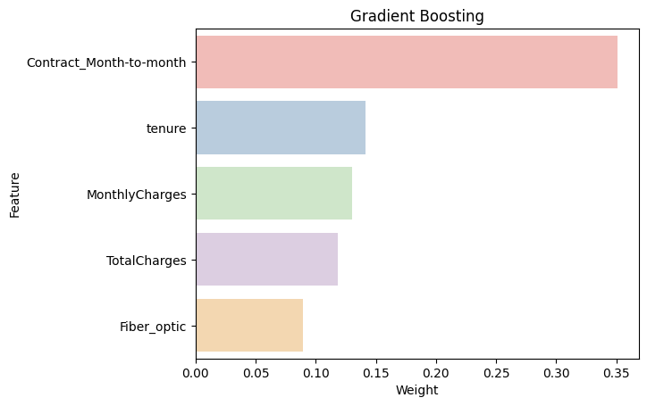

```python
# Obtaining feature importance
fi = pd.DataFrame({'Feature': list(X_train.columns),
                   'Importance': gb_model.feature_importances_}).\
                    sort_values('Importance', ascending = False)
fi.head()
# Plotting it
g = sns.barplot(x=fi["Importance"][0:5],y=fi["Feature"][0:5], palette="Pastel1",orient = "h")
g.set_xlabel("Weight")
g = g.set_title("Gradient Boosting");
```

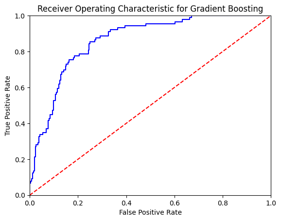

```python
# Calculate the fpr and tpr for all thresholds of the classification
fpr, tpr, threshold = roc_curve(y_test, gb_probs[:,1]);
plt.title('Receiver Operating Characteristic for Gradient Boosting');
plt.plot(fpr, tpr, 'b');
plt.plot([0, 1], [0, 1],'r--');
plt.xlim([0, 1]);
plt.ylim([0, 1]);
plt.ylabel('True Positive Rate');
plt.xlabel('False Positive Rate');
plt.show();
```

```python
# Save the model for Future use
filename = 'GB_Churn.sav'
pickle.dump(gb_model , open(filename,'wb'))
```

## Building XGB model

```python
# Building model with same Train Test split
xgb_model = XGBClassifier(max_depth=5, learning_rate=0.08)
xgb_model.fit(X_train, y_train)
print('Accuracy of XGB classifier on training set: {:.2f}'
       .format(xgb_model.score(X_train, y_train)))
print('Accuracy of XGB classifier on test set: {:.2f}'
       .format(xgb_model.score(X_test[X_train.columns], y_test)))
```

```
XGBClassifier(base_score=None, booster=None, callbacks=None,
              colsample_bylevel=None, colsample_bynode=None,
              colsample_bytree=None, early_stopping_rounds=None,
              enable_categorical=False, eval_metric=None, feature_types=None,
              gamma=None, gpu_id=None, grow_policy=None, importance_type=None,
              interaction_constraints=None, learning_rate=0.08, max_bin=None,
              max_cat_threshold=None, max_cat_to_onehot=None,
              max_delta_step=None, max_depth=5, max_leaves=None,
              min_child_weight=None, missing=nan, monotone_constraints=None,
              n_estimators=100, n_jobs=None, num_parallel_tree=None,
              predictor=None, random_state=None, ...)
```

```
Accuracy of XGB classifier on training set: 0.84
Accuracy of XGB classifier on test set: 0.80
```

```python
# Predicting using Extreme Gradient Boosting model and Probabilities
y_pred = xgb_model.predict(X_test)
xgb_probs = xgb_model.predict_proba(X_test)
print("Confusion Matrix: \n",confusion_matrix(y_test,y_pred),"\n")
print("Classification Report: \n",classification_report(y_test,y_pred),"\n")
print(accuracy_score(y_test, y_pred))
```

```
Confusion Matrix:
 [[238  26]
 [ 43  46]]

Classification Report:
               precision    recall  f1-score   support

           0       0.85      0.90      0.87       264
           1       0.64      0.52      0.57        89

    accuracy                           0.80       353
   macro avg       0.74      0.71      0.72       353
weighted avg       0.79      0.80      0.80       353


0.8045325779036827
```

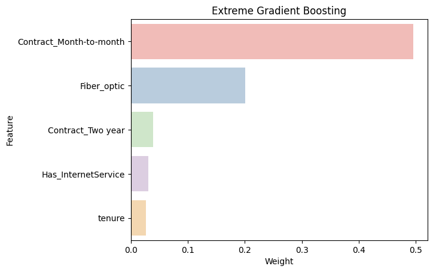

```python
# Obtaining feature importance
fi = pd.DataFrame({'Feature': list(X_train.columns),
                   'Importance': xgb_model.feature_importances_}).\
                    sort_values('Importance', ascending = False)
fi.head()
# Plotting it
g = sns.barplot(x=fi["Importance"][0:5],y=fi["Feature"][0:5], palette="Pastel1",orient = "h")
g.set_xlabel("Weight")
g = g.set_title("Extreme Gradient Boosting");
```

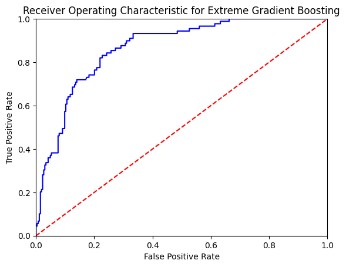

```python
# Calculate the fpr and tpr for all thresholds of the classification
fpr, tpr, threshold = roc_curve(y_test, xgb_probs[:,1]);
plt.title('Receiver Operating Characteristic for Extreme Gradient Boosting');
plt.plot(fpr, tpr, 'b');
plt.plot([0, 1], [0, 1],'r--');
plt.xlim([0, 1]);
plt.ylim([0, 1]);
plt.ylabel('True Positive Rate');
plt.xlabel('False Positive Rate');
plt.show();
```

```python
# Save the model for Future use
filename = 'XGB_Churn.sav'
pickle.dump(xgb_model , open(filename,'wb'))
```

## Building Decision tree model

```python
# Creaing a Decision tree model
classification_tree = tree.DecisionTreeClassifier(max_depth=4)
# Train our decision tree (tree induction + pruning)
classification_tree = classification_tree.fit(X_train, y_train)
```

```python
dot_data = tree.export_graphviz(classification_tree, out_file=None,
                     feature_names=X_train.columns,
                     class_names="Churn",
                     filled=True, rounded=True,
                     special_characters=True)
graph = graphviz.Source(dot_data)
graph.render("dot_data")
```

```
'dot_data.pdf'
```

```python
# 10 Folds Cross Validation
clf_score = cross_val_score(classification_tree, X_train, y_train, cv=10);
print(clf_score);
clf_score.mean()
```

```
[0.79820628 0.76831091 0.7922272  0.80269058 0.79073244 0.75635277
 0.7922272  0.78475336 0.7922272  0.79820628]
```

```
0.7875934230194319
```

[figure not shown]

```python
Rfclf_fea = pd.DataFrame(classification_tree.feature_importances_)
Rfclf_fea["Feature"] = list(X_train)
Rfclf_fea.sort_values(by=0, ascending=False).head()
g = sns.barplot(data = Rfclf_fea.sort_values(by=0, ascending=False)[0:5], palette="Pastel1",orient = "h")
g.set_xlabel("Weight")
g = g.set_title("Decision Tree");
```

```python
# Confusion Matrix
y_pred = classification_tree.predict(X_train)
probs = classification_tree.predict_proba(X_train)
print(confusion_matrix(y_train, y_pred))
# calculate AUC
auc = roc_auc_score(y_train, probs[:,1])
print('AUC: %.3f' % auc)
print(Y_train.shape)
print(probs.shape)
```

```
[[4380  530]
 [ 868  912]]
AUC: 0.839
(7043,)
(6690, 2)
```

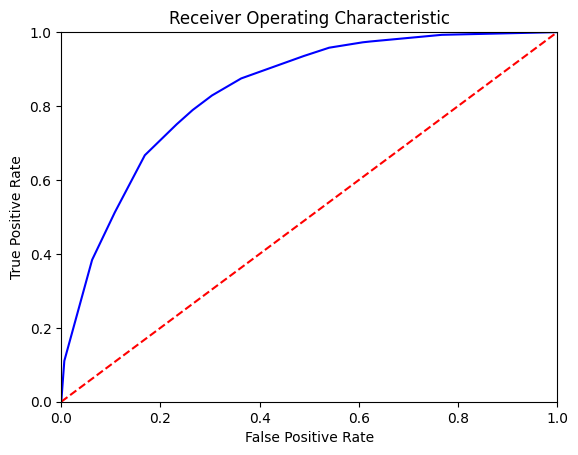

```python
# Calculate the fpr and tpr for all thresholds of the classification
fpr, tpr, threshold = roc_curve(y_train, probs[:,1])
plt.title('Receiver Operating Characteristic')
plt.plot(fpr, tpr, 'b')
plt.plot([0, 1], [0, 1],'r--')
plt.xlim([0, 1])
plt.ylim([0, 1])
plt.ylabel('True Positive Rate')
plt.xlabel('False Positive Rate')
plt.show();
```

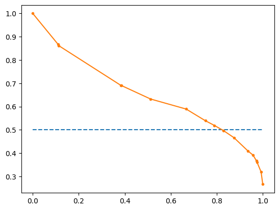

```python
precision, recall, thresholds = precision_recall_curve(y_train, probs[:,1])
# plot no skill
pyplot.plot([0, 1], [0.5, 0.5], linestyle='--');
# plot the roc curve for the model
pyplot.plot(recall, precision, marker='.');
```

## Building Random Forest With Oversampling

```python
# Instantialting Over sampling Random Forest Classifier and Model Fitting
sm = SMOTE(random_state = 10, sampling_strategy = 'minority')
X_train_res, y_train_res = sm.fit_resample(X_train, y_train)
rf_over = RandomForestClassifier(bootstrap = True, class_weight = None, criterion = 'gini', max_depth = 10,
                                   max_features = 'auto', max_leaf_nodes = None, min_impurity_decrease = 0.0,
                                   min_samples_leaf = 1, min_samples_split = 2,
                                   min_weight_fraction_leaf = 0.0, n_estimators = 20, n_jobs = -1,
                                   oob_score = False, random_state = 42, verbose = 0, warm_start = False)
rf_over.fit(X_train_res, y_train_res)
Train_score = rf_over.score(X_train_res, y_train_res)
Test_score = rf_over.score(X_test, y_test)
print("Training set accuracy: ", '%.3f'%(Train_score))
print("Test set accuracy: ", '%.3f'%(Test_score))
```

```
RandomForestClassifier(max_depth=10, max_features='auto', n_estimators=20,
                       n_jobs=-1, random_state=42)
```

```
Training set accuracy:  0.886
Test set accuracy:  0.796
```

```python
# Predicting using Oversampling RF model and Probabilities
y_pred = rf_over.predict(X_test)
rf_over_probs = rf_over.predict_proba(X_test)
print("Confusion Matrix: \n",confusion_matrix(y_test,y_pred),"\n")
print("Classification Report: \n",classification_report(y_test,y_pred),"\n")
print(accuracy_score(y_test, y_pred))
```

```
Confusion Matrix:
 [[219  45]
 [ 27  62]]

Classification Report:
               precision    recall  f1-score   support

           0       0.89      0.83      0.86       264
           1       0.58      0.70      0.63        89

    accuracy                           0.80       353
   macro avg       0.73      0.76      0.75       353
weighted avg       0.81      0.80      0.80       353


0.7960339943342776
```

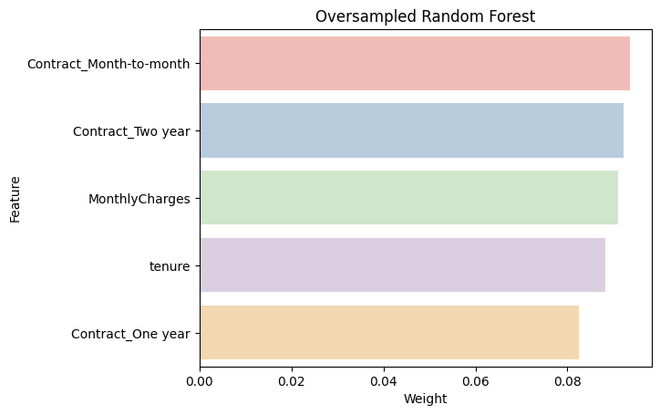

```python
# Obtaining feature importance
fi = pd.DataFrame({'Feature': list(X_train.columns),
                   'Importance': rf_over.feature_importances_}).\
                    sort_values('Importance', ascending = False)
fi.head()
# Plotting it
g = sns.barplot(x=fi["Importance"][0:5],y=fi["Feature"][0:5], palette="Pastel1",orient = "h")
g.set_xlabel("Weight")
g = g.set_title("Oversampled Random Forest");
```

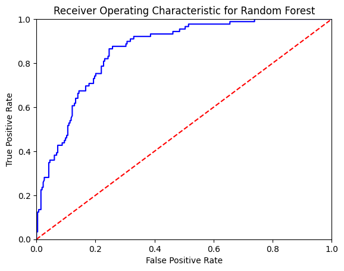

```python
# Calculate the fpr and tpr for all thresholds of the classification
fpr, tpr, threshold = roc_curve(y_test, rf_over_probs[:,1]);
plt.title('Receiver Operating Characteristic for Random Forest');
plt.plot(fpr, tpr, 'b');
plt.plot([0, 1], [0, 1],'r--');
plt.xlim([0, 1]);
plt.ylim([0, 1]);
plt.ylabel('True Positive Rate');
plt.xlabel('False Positive Rate');
plt.show();
```

```python
# Save the model for Future use
filename = 'ORF_Churn.sav'
pickle.dump(rf_over , open(filename,'wb'))
```

## Building Bagging Classifier

```python
# Instantialting Bagging Classifier and Model Fitting
bg = BaggingClassifier(n_estimators=10, random_state = 37)
bg.fit(X_train, y_train)
Train_score = bg.score(X_train, y_train)
Test_score = bg.score(X_test, y_test)
print("Training set accuracy: ", '%.3f'%(Train_score))
print("Test set accuracy: ", '%.3f'%(Test_score))
```

```
BaggingClassifier(random_state=37)
```

```
Training set accuracy:  0.979
Test set accuracy:  0.793
```

```python
# Predicting using Oversampling RF model and Probabilities
y_pred = bg.predict(X_test)
bg_probs = bg.predict_proba(X_test)
print("Confusion Matrix: \n",confusion_matrix(y_test,y_pred),"\n")
print("Classification Report: \n",classification_report(y_test,y_pred),"\n")
print(accuracy_score(y_test, y_pred))
```

```
Confusion Matrix:
 [[240  24]
 [ 49  40]]

Classification Report:
               precision    recall  f1-score   support

           0       0.83      0.91      0.87       264
           1       0.62      0.45      0.52        89

    accuracy                           0.79       353
   macro avg       0.73      0.68      0.70       353
weighted avg       0.78      0.79      0.78       353


0.7932011331444759
```

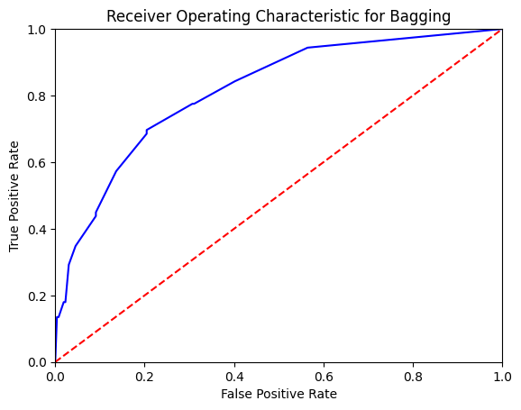

```python
# Calculate the fpr and tpr for all thresholds of the classification
fpr, tpr, threshold = roc_curve(y_test, bg_probs[:,1]);
plt.title('Receiver Operating Characteristic for Bagging');
plt.plot(fpr, tpr, 'b');
plt.plot([0, 1], [0, 1],'r--');
plt.xlim([0, 1]);
plt.ylim([0, 1]);
plt.ylabel('True Positive Rate');
plt.xlabel('False Positive Rate');
plt.show();
```

```python
# Save the model for Future use
filename = 'Bag_Churn.sav'
pickle.dump(bg , open(filename,'wb'))
```

```python
!jupyter nbconvert --to='html' /content/drive/MyDrive/AI_ML_course/NAYAN_ENSEMBLE_TECHNIQUE_PROJECT/NAYAN_SONAWANE_ENSEMBLE_TECHNIQUE_PROJECT_BERLIN.ipynb
```

[output not shown]

[output cut: 133 more lines]

[output not shown]